# Project 1 Proposal - Predicting Child Povery and Home Ownership in Counties of the Western Continental United States

## 0.1 Preliminaries

```r
library(simputation)
library(rms)
library(tidyverse)
```

# 1 Task 1: Data Source

The data in this study comes from the [Atlas of Rural and Small-Town America](https://www.ers.usda.gov/data-products/atlas-of-rural-and-small-town-america/), created by the Economic Research Service (ERS) of the the United States Department of Agriculture (USDA) with the objective “to better understand the economic, demographic, environmental, and social forces affecting rural regions and communities” (according to their [“Objectives” section](https://www.ers.usda.gov/data-products/atlas-of-rural-and-small-town-america/about-the-atlas/#objectives)). These data are primarily comprised of hundreds of socioeconomic measures at the county level. Though counties are the basic observation unit, the data also contain observations on the states, the District of Columbia, Puerto Rico and its municipalities, and the US as a whole.

The Atlas incorporates federal and state data gathered by the USDA ERS itself, the United States Census Bureau, the Bureau of Labor Statistics, the Bureau of Economic Analysis, the Office of Management and Budget, the Applied Population Laboratory of the University of Wisconsin-Madison, and state agencies on gas and oil production. Thus, the sampling methods for each statistic are diverse; details on the origins of specific variables in the Atlas can be found on its [Documentation page](https://www.ers.usda.gov/data-products/atlas-of-rural-and-small-town-america/documentation/). Regardless of the organization that collected the data for each variable, they are all representative county wide by definition.

## 1.1 The USDA ERS’s own description of the information contained in the Atlas

Excerpted from the [“About the Atlas” page](https://www.ers.usda.gov/data-products/atlas-of-rural-and-small-town-america/about-the-atlas/) on the ERS website:

“The Atlas assembles statistics on four broad categories of socioeconomic factors:

- People - Demographic data from the American Community Survey, including age, race and ethnicity, migration and immigration, education, household size and family composition. Data have been added on veterans, including service period, education, unemployment, income, and demographic characteristics
- Jobs - Economic data from the Bureau of Labor Statistics and other sources, including information on employment trends, unemployment, industrial composition, and household income
- Veterans - Indicators from the latest American Community Survey on the social and economic conditions of veterans
- County classifications - Rural-urban continuum, economic dependence, persistent poverty, population loss, oil/natural gas counties, and other ERS county codes."

## 1.2 How to obtain the Atlas data

The data can be downloaded at the [“Download the Data” page](https://www.ers.usda.gov/data-products/atlas-of-rural-and-small-town-america/download-the-data) as either a single .xlsx workbook or a .zip file that contains six .csv files.

I chose to work with the .zip folder of .csv files, and I only ended up using data from three of the .csv files: County Classifications.csv, Income.csv, and People.csv. I merged these three into a single .csv file called “Nik_Krieger-project1_data.csv”.

# 2 Task 2: Load and Tidy the Data

## 2.1 Data Load

```r
counties <- read.csv("Nik_Krieger-project1_data.csv") %>% tbl_df
```

As originally loaded, the `counties` data set contains 3278 rows and 138 columns.

As stated above, explanations of each of the original variables in these data sets are found at the Atlas’s [Documentation page](https://www.ers.usda.gov/data-products/atlas-of-rural-and-small-town-america/documentation/).

## 2.2 Tidying, Data Cleaning and Data Management

The following code chunk selects only the variables of interest in the study, renames some variables, and recodes some factors.

```r
counties <- counties %>%
            mutate(EconomicType = fct_recode(as.factor(Type_2015_Update),
                   "Nonspecialized" = "0", "Farm-dependent" = "1",
                   "Mining-dependent" = "2", "Manufacturing-dependent" = "3",
                   "Federal/State government-dependent" = "4", "Recreation county" = "5")) %>%
            rename(PersistentChildPov = PersistentChildPoverty_1980_2011) %>%
            filter(State %in% c("WA", "OR", "CA", "ID", "MT", "WY", "NV", "UT", "CO", "AZ", "NM"),
                   FIPS %% 1000 != 0) %>%
            mutate(County = paste(County, State, sep=", ")) %>%
            mutate(State = fct_recode(State,
                   "Washington" = "WA", "Oregon" = "OR", "California" = "CA", "Idaho" = "ID",
                   "Montana" = "MT", "Wyoming" = "WY", "Nevada" = "NV", "Utah" = "UT",
                   "Colorado" = "CO", "Arizona" = "AZ", "New Mexico" = "NM")) %>%
            select(County, State, EconomicType, HiAmenity, AvgHHSize, FemaleHHPct,
                   OwnHomePct, PersistentChildPov) %>%
            droplevels()
```

Here are explanations of each piece of the code chunk above.

### 2.2.1 Renaming `Type_2015_Update` to `EconomicType` and turning it into a factor

The code:

```
    mutate(EconomicType = fct_recode(as.factor(Type_2015_Update),
           "Nonspecialized" = "0", "Farm-dependent" = "1",
           "Mining-dependent" = "2", "Manufacturing-dependent" = "3",
           "Federal/State government-dependent" = "4", "Recreation county" = "5"))
```

`Type_2015_Update` is originally coded with integers 0-5. It is recoded here as a factor with explicit level names, taken from the [Documentation page](https://www.ers.usda.gov/data-products/atlas-of-rural-and-small-town-america/documentation/). This new, recoded variable is called `EconomicType`.

### 2.2.2 Renaming `PersistentChildPoverty_1980_2011` to `PersistentChildPov`

The code:

```
    rename(PersistentChildPov = PersistentChildPoverty_1980_2011)
```

The variable name `PersistentChildPoverty_1980_2011` is way too long. I renamed it to the more tolerable `PersistentChildPov`.

### 2.2.3 Paring down to the subset of interest

The code:

```
    filter(State %in% c("WA", "OR", "CA", "ID", "MT", "WY", "NV", "UT", "CO", "AZ", "NM"),
           FIPS %% 1000 != 0)
```

The first line filters pares the data down to include only counties in states that are in the West Region of the US, as determined by the US Census Bureau, and furthermore, Alaska and Hawaii are excluded.

The second line serves to remove observations that contain aggregate data on the states themselves, rather than counties (in the raw data, states have FIPS codes divisible by 1000, whereas counties do not).

### 2.2.4 Adding the state abbreviations to the names of each county

The code:

```
    mutate(County = paste(County, State, sep=", "))
```

In order to ensure that each observation would have a unique identifier–and to facilitate the identification of observations–the value of `State` (the two-letter state abbreviation) was appended onto the end of values of `County` (the name of each county) with a comma and a space in between. For example, the name of Cuyahoga county of Ohio would be changed from “Cuyahoga” to “Cuyahoga, OH”.

### 2.2.5 Making the `State` level names explicit

The code:

```
    mutate(State = fct_recode(State,
           "Washington" = "WA", "Oregon" = "OR", "California" = "CA", "Idaho" = "ID",
           "Montana" = "MT", "Wyoming" = "WY", "Nevada" = "NV", "Utah" = "UT",
           "Colorado" = "CO", "Arizona" = "AZ", "New Mexico" = "NM"))
```

The raw data used the two-letter abbreviations in the `State` variable. Here, they were changed into their corresponding full-length names.

### 2.2.6 Paring down to the variables of interest

The code:

```
    select(County, State, EconomicType, HiAmenity, AvgHHSize, FemaleHHPct,
           OwnHomePct, PersistentChildPov)
```

We pared down to the variables that are actually used for this project.

### 2.2.7 Drop old levels

The code:

```
    droplevels()
```

Finally, we removed all levels of factor variables that are no longer present in our tidied data set.

## 2.3 Missingness Check

Here are the observations with missingness in our variables of interest:

```r
counties %>% filter(rowSums(is.na(.)) > 0)
```

| County | State | EconomicType | HiAmenity | AvgHHSize | FemaleHHPct | OwnHomePct | PersistentChildPov |
| --- | --- | --- | --- | --- | --- | --- | --- |
| Broomfield, CO | Colorado | Nonspecialized | NA | 2.6 | 7.8 | 68.4 | 0 |

There is exactly one missing value: the county of Broomfield in Colorado is missing a value under the `HiAmenity` variable.

This is very fortunate, and there is no reason to believe that there is any kind of missingness pattern. We’ll impute this value of `HiAmenity` now using the function `simputation::impute_rlm()` and employing all other predictor variables.

```r
counties <- counties %>%
  impute_rlm(HiAmenity ~ State + EconomicType + AvgHHSize + FemaleHHPct)

counties %>% filter(County == "Broomfield, CO")
```

| County | State | EconomicType | HiAmenity | AvgHHSize | FemaleHHPct | OwnHomePct | PersistentChildPov |
| --- | --- | --- | --- | --- | --- | --- | --- |
| Broomfield, CO | Colorado | Nonspecialized | 1 | 2.6 | 7.8 | 68.4 | 0 |

We see that Broomfield, CO has been deemed a high-amenity county (i.e., `HiAmenity` = 1).

# 3 Task 3: Listing of My Tibble

Our tibble `counties` contains 414 rows (patients) and 8 columns (variables). Each variable is contained in a column, and each row represents a single subject. All variables now have appropriate types.

```r
counties
```

|  | County | State | EconomicType | HiAmenity | AvgHHSize | FemaleHHPct | OwnHomePct | PersistentChildPov |
| --- | --- | --- | --- | --- | --- | --- | --- | --- |
| 1 | Ada, ID | Idaho | Nonspecialized | 1 | 2.6 | 9.0 | 67.3 | 0 |
| 2 | Adams, ID | Idaho | Federal/State government-dependent | 1 | 2.4 | 9.6 | 77.1 | 0 |
| 3 | Bannock, ID | Idaho | Federal/State government-dependent | 1 | 2.7 | 10.8 | 66.8 | 0 |
| 4 | Bear Lake, ID | Idaho | Recreation county | 1 | 2.5 | 7.1 | 79.6 | 0 |
| 5 | Benewah, ID | Idaho | Nonspecialized | 1 | 2.5 | 9.5 | 72.2 | 0 |
| 6 | Bingham, ID | Idaho | Nonspecialized | 1 | 3.1 | 9.3 | 74.1 | 0 |
| 7 | Blaine, ID | Idaho | Recreation county | 1 | 2.4 | 8.6 | 65.9 | 0 |
| 8 | Boise, ID | Idaho | Federal/State government-dependent | 1 | 2.3 | 5.5 | 82.5 | 0 |
| 9 | Bonner, ID | Idaho | Recreation county | 1 | 2.4 | 8.8 | 72.7 | 0 |
| 10 | Bonneville, ID | Idaho | Nonspecialized | 1 | 2.9 | 11.1 | 71.6 | 0 |

[output cut: 404 more lines]

```r
counties %>% str()
```

```
Classes 'tbl_df', 'tbl' and 'data.frame':   414 obs. of  8 variables:
 $ County            : chr  "Ada, ID" "Adams, ID" "Bannock, ID" "Bear Lake, ID" ...
 $ State             : Factor w/ 11 levels "Arizona","California",..: 4 4 4 4 4 4 4 4 4 4 ...
 $ EconomicType      : Factor w/ 6 levels "Nonspecialized",..: 1 5 5 6 1 1 6 5 6 1 ...
 $ HiAmenity         : num  1 1 1 1 1 1 1 1 1 1 ...
 $ AvgHHSize         : num  2.6 2.4 2.7 2.5 2.5 3.1 2.4 2.3 2.4 2.9 ...
 $ FemaleHHPct       : num  9 9.6 10.8 7.1 9.5 9.3 8.6 5.5 8.8 11.1 ...
 $ OwnHomePct        : num  67.3 77.1 66.8 79.6 72.2 74.1 65.9 82.5 72.7 71.6 ...
 $ PersistentChildPov: int  0 0 0 0 0 0 0 0 0 0 ...
```

# 4 Task 4: Code Book

| Variable | Type | Details |
| --- | --- | --- |
| `County` | character | County name followed by its state abbreviation |
| `State` | multi-categorical | State name (Washington, Oregon, California, Idaho, Montana, Wyoming, Colorado, Utah, Nevada, Arizona, and New Mexico) |
| `EconomicType` | multi-categorical | Classification according to employment data |
| `HiAmenity` | binary | Yes or No: Does this county have high natural amenities? |
| `AvgHHSize` | quantitative | Average household size |
| `FemaleHHPct` | quantitative | Percentage of households headed by a female |
| `OwnHomePct` | quantitative | Percentage of residences occupied by their owners |
| `PersistentChildPov` | binary | Yes or No: Does this county have consistent child poverty? |

# 5 Task 5: My Subjects

Each of the 414 rows provides demographic data on a county in the Western United States (as determined by the US Census Bureau), with the exception of counties in Alaska and Hawaii.

# 6 Task 6: My Variables

There are 8 variables in the `counties` data set. All quotations in the descriptions below are taken from the Atlas’s [Documentation page](https://www.ers.usda.gov/data-products/atlas-of-rural-and-small-town-america/documentation/):

1. **County**
   - This is the name of the county followed by a comma, a space, and the two-letter abbreviation of the state in which the county is located.
2. **State**
   - This is the name of the state in which the county is located. This will be either “Washington”, “Oregon”, “California”, “Idaho”, “Montana”, “Wyoming”, “Utah”, “Colorado”, “Nevada”, “Arizona”, or “New Mexico”.
3. **EconomicType**
   - This is a “classification of counties by measures of earnings and employment.” This will be either “Nonspecialized”, “Farm-dependent”, “Mining-dependent”, “Manufacturing-dependent”, “Federal/State government-dependent”, or “Recreation county”. Counties were classified according to 2010-2012 “multi-year averages and point-in-time census data” from the U.S. Department of Agriculture, Economic Research Service, and County Typology Codes, using data from the Bureau of Economic Analysis and the U.S. Census Bureau.
4. **HiAmenity**
   - This is a binary “classification of counties by physical attributes, where 1=high natural amenities county [and] 0=all other counties; a high natural amenities county falls in the top quartile of counties ranked by the ERS natural amenities scale; the scale combines six measures of climate, topography, and water area that reflect environmental qualities most people prefer.” The data comes from the U.S. Department of Agriculture, Economic Research Service, and the Natural Amenity Scale and is considered “mostly time invariant.”
5. **AvgHHSize**
   - This is the county’s average household size (i.e., the “number of people in the county divided by the number of households”) according to a multi-year average of monthly surveys by the U.S. Census bureau and the American Community Survey, 2011-15.
6. **FemaleHHPct**
   - This is the “percent of county households headed by a female with no husband present,” according to a multi-year average of monthly surveys by the U.S. Census bureau and the American Community Survey, 2011-15.
7. **OwnHomePct**
   - THis is the county-wide “percent of homes owned and occupied by the owner” according to a multi-year average of monthly surveys by the U.S. Census bureau and the American Community Survey, 2011-15.
8. **PersistentChildPov**
   - This is a binary “classification of counties by level of poverty over four decades, where 1=persistent child poverty county [and] 0=all other counties; a county was classified as persistent poverty if 20 percent or more of related children under 18 years were poor as measured by the 1980, 1990, and 2000 decennial censuses and the American Community Survey 5-year estimates for 2007-2011.”

# 7 Task 7: My Planned Linear Regression Model

We will predict the quantitative outcome **OwnHomePct** using the following variables:

- `State`
- `EconomicType`
- `HiAmenity`
- `AvgHHSize`
- `FemaleHHPct`

`State` and `EconomicType` are both multi-categorical predictors. `AvgHHSize` and `FemaleHHPct` are both quantitative predictors.

# 8 Task 8: My Planned Logistic Regression Model

We will predict the binary outcome **PersistentChildPov** using the following variables:

- `State`
- `EconomicType`
- `HiAmenity`
- `AvgHHSize`
- `FemaleHHPct`

`State` and `EconomicType` are both multi-categorical predictors. `AvgHHSize` and `FemaleHHPct` are both quantitative predictors.

# 9 Task 9: Affirmation

My data set meets all of the requirements specified in the project instructions.

- With 414 observations, it falls between the minimum (100) and maximum (1000) sample size.
- It contains 5 predictors, two being quantitative and two being multi-categorical.
- One outcome variable is binary and one outcome variable is quantitative.
- I am certain that it is completely appropriate for these data to be shared with anyone, without any conditions. There are no concerns about privacy or security.

# 10 Task 10: Linear Regression

We begin by creating a Spearman $\rho^2$ plot to see which variables may be the most consequential to the quantitative outcome of `OwnHomePct`.

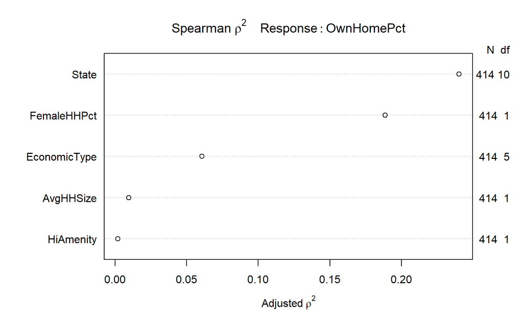

```r
plot(Hmisc::spearman2(OwnHomePct ~ State + EconomicType + HiAmenity + AvgHHSize + FemaleHHPct, data=counties))
```

It is clear that `State` and `FemaleHHPct` are clearly the most important predictors to this variable. Unfortunately, fitting interaction terms for the `State` variable would put us over the edge of the n/15 rule; since we have n=414, we don’t want more than 27 coefficients in our model. We have 19 terms as it is (including the intercept), so we can’t afford to add another 10 interaction terms. Therefore, we will add splines to the `FemaleHHPct` variable as well as interaction terms between `FemaleHHPct` and `EconomicType`.

```r
d.lm <- datadist(counties)
options(datadist = "d.lm")

t10.model <- ols(OwnHomePct ~ State + rcs(FemaleHHPct, 5) + EconomicType +
                   FemaleHHPct %ia% EconomicType + HiAmenity + AvgHHSize,
                 data=counties, x = TRUE, y = TRUE)
summary(t10.model)
```

```
             Effects              Response : OwnHomePct

 Factor                                                           Low
 FemaleHHPct                                                      7.2
 HiAmenity                                                        0.0
 AvgHHSize                                                        2.3
 State - Arizona:Colorado                                         3.0
 State - California:Colorado                                      3.0
 State - Idaho:Colorado                                           3.0
 State - Montana:Colorado                                         3.0
 State - New Mexico:Colorado                                      3.0
 State - Nevada:Colorado                                          3.0
 State - Oregon:Colorado                                          3.0
 State - Utah:Colorado                                            3.0
 State - Washington:Colorado                                      3.0
 State - Wyoming:Colorado                                         3.0
 EconomicType - Farm-dependent:Nonspecialized                     1.0
 EconomicType - Mining-dependent:Nonspecialized                   1.0
 EconomicType - Manufacturing-dependent:Nonspecialized            1.0
 EconomicType - Federal/State government-dependent:Nonspecialized 1.0
 EconomicType - Recreation county:Nonspecialized                  1.0
 High   Diff. Effect    S.E.    Lower 0.95 Upper 0.95
 11.475 4.275 -3.943100 1.19680 -6.296200  -1.59000
  1.000 1.000  1.293900 1.08940 -0.847960   3.43580
  2.800 0.500  0.133440 0.69298 -1.229000   1.49590
  1.000    NA  1.797700 2.06110 -2.254700   5.85010
  2.000    NA -5.480100 1.32200 -8.079300  -2.88090
  4.000    NA  2.431100 1.38180 -0.285690   5.14790
  5.000    NA  0.860340 1.27180 -1.640100   3.36080
  6.000    NA  6.883200 1.54900  3.837600   9.92870
  7.000    NA -1.187300 1.88020 -4.884000   2.50950
  8.000    NA -3.351500 1.42010 -6.143500  -0.55952
  9.000    NA  6.371000 1.76400  2.902700   9.83930
 10.000    NA -0.261020 1.38750 -2.989000   2.46700
 11.000    NA  1.815200 1.68910 -1.505800   5.13630
  2.000    NA  2.396300 1.20760  0.022015   4.77070
  3.000    NA  0.241170 1.25360 -2.223600   2.70600
  4.000    NA -0.066773 2.31640 -4.621100   4.48760
  5.000    NA -0.879570 1.04680 -2.937700   1.17860
  6.000    NA  1.246300 1.00250 -0.724850   3.21740

Adjusted to: FemaleHHPct=9.3 EconomicType=Nonspecialized
```

```r
anova(t10.model)
```

```
                Analysis of Variance          Response: OwnHomePct

 Factor                                                    d.f.
 State                                                      10
 FemaleHHPct  (Factor+Higher Order Factors)                  9
  All Interactions                                           5
  Nonlinear                                                  3
 EconomicType  (Factor+Higher Order Factors)                10
  All Interactions                                           5
 FemaleHHPct * EconomicType  (Factor+Higher Order Factors)   5
 HiAmenity                                                   1
 AvgHHSize                                                   1
 TOTAL NONLINEAR + INTERACTION                               8
 REGRESSION                                                 26
 ERROR                                                     387
 Partial SS   MS         F     P
  4417.042175 441.704218 10.26 <.0001
  2155.418129 239.490903  5.56 <.0001
    84.633686  16.926737  0.39 0.8535
   295.910593  98.636864  2.29 0.0778
   469.480203  46.948020  1.09 0.3681
    84.633686  16.926737  0.39 0.8535
    84.633686  16.926737  0.39 0.8535
    60.733901  60.733901  1.41 0.2357
     1.596317   1.596317  0.04 0.8474
   461.226027  57.653253  1.34 0.2224
 10498.897313 403.803743  9.38 <.0001
 16660.792252  43.051143
```

# 11 Task 11: Logistic Regression

```r
t11.model <- glm(PersistentChildPov ~ State + EconomicType + HiAmenity + AvgHHSize + FemaleHHPct, data=counties, family=binomial)
summary(t11.model)
```

```
Call:
glm(formula = PersistentChildPov ~ State + EconomicType + HiAmenity +
    AvgHHSize + FemaleHHPct, family = binomial, data = counties)

Deviance Residuals:
     Min        1Q    Median        3Q       Max
-1.75179  -0.40016  -0.21455  -0.00025   2.93394

Coefficients:
                                                 Estimate Std. Error
(Intercept)                                      -8.21650    2.07174
StateCalifornia                                  -2.52372    0.83310
StateColorado                                    -0.07274    0.75609
StateIdaho                                       -2.85167    1.27496
StateMontana                                      0.45882    0.82731
StateNew Mexico                                   1.09855    0.75193
StateNevada                                     -17.07615 1423.22212
StateOregon                                      -1.44168    0.97546
StateUtah                                        -2.12528    1.30910
StateWashington                                  -2.65699    1.22381
StateWyoming                                    -16.03776 1274.59757
EconomicTypeFarm-dependent                        1.52673    0.61646
EconomicTypeMining-dependent                     -0.39351    0.79923
EconomicTypeManufacturing-dependent             -16.71467 1814.81268
EconomicTypeFederal/State government-dependent    0.60735    0.53975
EconomicTypeRecreation county                     0.69482    0.59397
HiAmenity                                         0.73441    0.63888
AvgHHSize                                         0.88009    0.73061
FemaleHHPct                                       0.34768    0.08009
                                               z value Pr(>|z|)
(Intercept)                                     -3.966 7.31e-05 ***
StateCalifornia                                 -3.029  0.00245 **
StateColorado                                   -0.096  0.92335
StateIdaho                                      -2.237  0.02531 *
StateMontana                                     0.555  0.57918
StateNew Mexico                                  1.461  0.14402
StateNevada                                     -0.012  0.99043
StateOregon                                     -1.478  0.13942
StateUtah                                       -1.623  0.10449
StateWashington                                 -2.171  0.02992 *
StateWyoming                                    -0.013  0.98996
EconomicTypeFarm-dependent                       2.477  0.01326 *
EconomicTypeMining-dependent                    -0.492  0.62246
EconomicTypeManufacturing-dependent             -0.009  0.99265
EconomicTypeFederal/State government-dependent   1.125  0.26049
EconomicTypeRecreation county                    1.170  0.24208
HiAmenity                                        1.150  0.25034
AvgHHSize                                        1.205  0.22836
FemaleHHPct                                      4.341 1.42e-05 ***
---
Signif. codes:  0 '***' 0.001 '**' 0.01 '*' 0.05 '.' 0.1 ' ' 1

(Dispersion parameter for binomial family taken to be 1)

    Null deviance: 335.45  on 413  degrees of freedom
Residual deviance: 195.56  on 395  degrees of freedom
AIC: 233.56

Number of Fisher Scoring iterations: 17
```

```r
exp(coef(t11.model))
```

```
                                   (Intercept)
                                  2.701595e-04
                               StateCalifornia
                                  8.016062e-02
                                 StateColorado
                                  9.298393e-01
                                    StateIdaho
                                  5.774783e-02
                                  StateMontana
                                  1.582202e+00
                               StateNew Mexico
                                  2.999827e+00
                                   StateNevada
                                  3.836391e-08
                                   StateOregon
                                  2.365305e-01
                                     StateUtah
                                  1.193992e-01
                               StateWashington
                                  7.015873e-02
                                  StateWyoming
                                  1.083649e-07
                    EconomicTypeFarm-dependent
                                  4.603119e+00
                  EconomicTypeMining-dependent
                                  6.746841e-01
           EconomicTypeManufacturing-dependent
                                  5.506956e-08
EconomicTypeFederal/State government-dependent
                                  1.835555e+00
                 EconomicTypeRecreation county
                                  2.003344e+00
                                     HiAmenity
                                  2.084254e+00
                                     AvgHHSize
                                  2.411114e+00
                                   FemaleHHPct
                                  1.415780e+00
```

Nik Krieger

2018-03-07 21:57:21